# NB and ZINB Regression: Building and Benchmarking an R Package

Abigail Amoah

2026-11-15

# 1 Introduction

Count data arise frequently in applied statistics: the number of physician office visits, the number of articles published, or the number of insurance claims. The simplest model for count data is the Poisson regression, which assumes that the mean equals the variance. In practice, two violations are common:

**Overdispersion.** The variance often exceeds the mean. The negative binomial (NB) model addresses this by introducing a dispersion parameter $\theta > 0$ so that $\text{Var}(Y_i) = \mu_i + \mu_i^2/\theta$. As $\theta \to \infty$ the model reduces to the Poisson.

**Excess zeros.** Many count datasets contain more zeros than a Poisson (or even NB) distribution predicts. The zero-inflated negative binomial (ZINB) model (Lambert 1992) handles this through a two-component mixture: with probability $\pi_i$ the observation is a structural zero (e.g., a person who never visits a doctor); with probability $1-\pi_i$ it comes from an NB distribution, which can itself produce zeros.

This report documents the **nbzinbAmoah** R package, which fits both models from scratch using iteratively reweighted least squares (IRLS) (McCullagh and Nelder 1989) and an expectation-maximisation (EM) algorithm — without any general-purpose optimizer. We benchmark our implementation against the reference functions `MASS::glm.nb()` (Venables and Ripley 2002) and `pscl::zeroinfl()` (Zeileis et al. 2008), and apply the package to the NMES1988 dataset from the **AER** package (Kleiber and Zeileis 2008).

# 2 Methods

## 2.1 Negative Binomial Regression

Let $Y_i$ be a count and $x_i$ a $p$-vector of covariates, $i = 1, \ldots, n$. The NB2 model assumes
$$P(Y_i = y) = \frac{\Gamma(y+\theta)}{\Gamma(\theta)\,y!}
\left(\frac{\theta}{\theta+\mu_i}\right)^\theta
\left(\frac{\mu_i}{\theta+\mu_i}\right)^y, \quad y = 0,1,2,\ldots$$
with log link $\log\mu_i = \eta_i = x_i^\top\beta + o_i$, where $o_i$ is an optional offset. Then $E(Y_i) = \mu_i$ and $\text{Var}(Y_i) = \mu_i + \mu_i^2/\theta$. With prior weights $a_i$ ($a_i = 1$ for an ordinary fit) the log-likelihood is
$$\ell(\beta,\theta) = \sum_{i=1}^n a_i\Bigl[\log\Gamma(y_i+\theta) - \log\Gamma(\theta)
- \log y_i! + \theta\log\theta + y_i\log\mu_i - (\theta+y_i)\log(\theta+\mu_i)\Bigr].$$
This is the parameterisation used by `MASS::glm.nb()`, whose `theta` is the same $\theta$.

**IRLS for $\beta$ (with $\theta$ fixed).** For a GLM with log link and variance $V(\mu) = \mu + \mu^2/\theta$, Fisher scoring is equivalent to repeated weighted least squares with working weights and working response
$$w_i = a_i\,\frac{(\partial\mu_i/\partial\eta_i)^2}{V(\mu_i)}
= a_i\,\frac{\theta\,\mu_i}{\theta + \mu_i}, \qquad
z_i = (\eta_i - o_i) + \frac{y_i - \mu_i}{\mu_i},$$
$$\beta^{(t+1)} = (X^\top W X)^{-1} X^\top W z, \qquad W = \text{diag}(w_1,\ldots,w_n).$$
The weighted least-squares step is computed with `solve()`; `lm()`, `lm.wfit()` and `glm.fit()` are not used.

**Newton–Raphson for $\theta$ (with $\beta$ fixed).** The score and second derivative of $\ell$ with respect to $\theta$ are
$$U(\theta) = \sum_i a_i\Bigl[\psi(y_i+\theta) - \psi(\theta) + \log\theta + 1
- \log(\theta+\mu_i) - \frac{y_i+\theta}{\theta+\mu_i}\Bigr],$$
$$H(\theta) = \sum_i a_i\Bigl[\psi'(y_i+\theta) - \psi'(\theta) + \frac{1}{\theta}
- \frac{2}{\theta+\mu_i} + \frac{y_i+\theta}{(\theta+\mu_i)^2}\Bigr],$$
where $\psi$ and $\psi'$ are `digamma()` and `trigamma()`. We update $\phi = \log\theta$, which keeps $\theta > 0$. By the chain rule $U_\phi = \theta U$ and $H_\phi = \theta^2 H + \theta U$, and the update is $\phi \leftarrow \phi - U_\phi / H_\phi$.

**Standard errors.** At convergence, $\widehat{\text{Var}}(\hat\beta) = (X^\top\hat W X)^{-1}$, treating $\hat\theta$ as known as `glm.nb()` does, and $\text{SE}(\hat\theta) = \{-H(\hat\theta)\}^{-1/2}$. The package stores $\text{SE}(\log\hat\theta) = (-H_\phi)^{-1/2}$. Because $U(\hat\theta) = 0$ at the MLE, $H_\phi = \hat\theta^2 H$, so $\text{SE}(\hat\theta) = \hat\theta\,\text{SE}(\log\hat\theta)$.

## 2.2 Zero-Inflated Negative Binomial Regression

The ZINB model is a two-component mixture. Let $D_i = 1$ if observation $i$ is a structural zero, with $P(D_i = 1) = \pi_i$; otherwise $Y_i$ comes from an $\text{NB}(\mu_i, \theta)$ distribution, which can itself produce zeros:
$$P(Y_i = 0) = \pi_i + (1-\pi_i)\,f_\text{NB}(0;\mu_i,\theta), \qquad
P(Y_i = y) = (1-\pi_i)\,f_\text{NB}(y;\mu_i,\theta), \quad y \ge 1,$$
where $f_\text{NB}(0;\mu,\theta) = \{\theta/(\theta+\mu)\}^\theta$, $\log\mu_i = x_i^\top\beta + o_i$ (count model) and $\text{logit}\,\pi_i = z_i^\top\gamma$ (zero-inflation model). The covariates $z_i$ may differ from $x_i$, and the marginal mean is $E(Y_i) = (1-\pi_i)\mu_i$. The observed-data log-likelihood is
$$\ell(\beta,\gamma,\theta) = \sum_{i:\,y_i=0}\log\bigl[\pi_i + (1-\pi_i)\,f_\text{NB}(0;\mu_i,\theta)\bigr]
+ \sum_{i:\,y_i>0}\bigl[\log(1-\pi_i) + \log f_\text{NB}(y_i;\mu_i,\theta)\bigr].$$
Because of the mixture, $\ell$ is **not** the log-likelihood of an exponential-family GLM, so IRLS cannot be applied to it directly (`pscl::zeroinfl()` maximises it with the general-purpose optimiser BFGS). Instead we use an **EM algorithm** (Dempster et al. 1977) that treats $D_i$ as missing data. Given $D_i$, the complete-data log-likelihood splits into a logistic part in $\gamma$ and a weighted NB part in $(\beta, \theta)$, and each part can be fitted by IRLS.

**E-step.** Given the current $(\beta, \gamma, \theta)$, compute the posterior probability that observation $i$ is a structural zero:
$$\tau_i = P(D_i = 1 \mid y_i) = \begin{cases}
\dfrac{\pi_i}{\pi_i + (1-\pi_i)\,f_\text{NB}(0;\mu_i,\theta)} & y_i = 0,\\
0 & y_i > 0.
\end{cases}$$

**M-step (zero part).** Maximise $\sum_i[\tau_i\log\pi_i + (1-\tau_i)\log(1-\pi_i)]$ over $\gamma$. This is a logistic regression with a *fractional* response $\tau_i$, fitted by IRLS with
$$w_i = \pi_i(1-\pi_i), \qquad
\tilde z_i = z_i^\top\gamma + \frac{\tau_i - \pi_i}{\pi_i(1-\pi_i)}, \qquad
\gamma \leftarrow (Z^\top W Z)^{-1} Z^\top W \tilde z.$$
(We write $\tilde z_i$ for the working response, to distinguish it from the covariate vector $z_i$.)

**M-step (count part).** Maximise $\sum_i(1-\tau_i)\log f_\text{NB}(y_i;\mu_i,\theta)$ over $(\beta,\theta)$. This is exactly the NB fit of Section 2.1 with prior weights $a_i = 1-\tau_i$, so the same IRLS and Newton–Raphson updates are reused.

**Convergence.** The E- and M-steps are repeated until the observed-data log-likelihood $\ell(\beta,\gamma,\theta)$ changes by less than the tolerance. EM never decreases $\ell$; `zinbreg()` checks this at every iteration and issues a warning if it ever happens.

**Standard errors.** EM does not produce standard errors. We compute the observed information matrix as the negative Hessian of our own observed-data log-likelihood with respect to $(\beta, \gamma, \log\theta)$ at the MLE, using `numDeriv::hessian()` (numerical differentiation, not optimisation), and invert it. As `zeroinfl()` does, we report $\log\hat\theta$ with its standard error, and also $\hat\theta$.

## 2.3 Algorithms and Convergence Criteria

**NB (`nbreg()`).** $\beta$ starts from one Poisson-type weighted least-squares step: $\log\max(y_i, 0.5) - o_i$ is regressed on $X$ with weights $\max(y_i, 0.5)$, which is a Poisson IRLS step started from $\mu_i = y_i$. $\theta$ starts from the moment estimator $\hat\theta_0 = \bar y^2 / (s^2 - \bar y)$ (set to 1 if $s^2 \le \bar y$, and at least 0.1). The outer loop alternates (a) IRLS for $\beta$, iterated until $\max_j|\Delta\beta_j| < 10^{-10}$, and (b) Newton–Raphson for $\log\theta$. It stops when the log-likelihood changes by less than `epsilon` (default $10^{-8}$), or after `maxit` (default 200) outer iterations.

**ZINB (`zinbreg()`).** $(\beta, \theta)$ start from an `nbreg()` fit of the count model. $\gamma$ starts with its intercept at the logit of the observed proportion of zeros and its other coefficients at zero. Each EM iteration runs one E-step and both M-steps, and the algorithm stops when $\ell$ changes by less than `epsilon` (default $10^{-8}$), or after `maxit` (default 300) iterations. The benchmarks below use the tighter `epsilon = 1e-10`.

# 3 The R Package

## 3.1 Design and Main Functions

The **nbzinbAmoah** package exports four user-facing functions:

| Function | Purpose |
| --- | --- |
| `nbreg(formula, data, offset, control, weights)` | NB regression via IRLS + Newton–Raphson for $\theta$ |
| `zinbreg(formula, data, offset, control, weights)` | ZINB via EM with IRLS M-steps |
| `nbreg_control(maxit, theta_maxit, epsilon, trace)` | Tolerances and iteration limits for `nbreg` |
| `zinbreg_control(maxit, irls_maxit, theta_maxit, epsilon, trace)` | Tolerances and iteration limits for `zinbreg` |

Both fitting functions return S3 objects (classes `"nbreg"` and `"zinbreg"`) containing the coefficients, variance–covariance matrix, $\hat\theta$ and its standard error, log-likelihood, number of iterations, a convergence flag, fitted values and the matched call. Methods are provided for `print`, `summary` (a coefficient table of estimates, SEs, $z$ values and $p$-values, printed by a `print.summary` method), `coef`, `vcov`, `logLik` (with a `df` attribute, so `AIC()` and `BIC()` work), `fitted`, `residuals` (`type = "response"` or `"pearson"`), `nobs`, and `predict` (with `newdata`). For `zinbreg`, `coef()` and `vcov()` take `model = "count"`, `"zero"` or `"full"`, and `predict()` supports `type = "response"` ($(1-\pi)\mu$), `"count"` ($\mu$) and `"zero"` ($\pi$).

The `zinbreg` formula uses the two-part syntax `y ~ x1 + x2 | z1 + z2` from the **Formula** package: count-model covariates before the bar and zero-model covariates after it. Without `|`, the same covariates are used in both parts, as in `zeroinfl()`.

## 3.2 Installation

```r
devtools::install_github("AbigailAmoah/nbzinbAmoah")
library(nbzinbAmoah)
```

## 3.3 Usage Example

```r
# Fit NB and ZINB on bioChemists (for illustration)
fit_nb_ex <- nbreg(art ~ fem + mar + kid5 + phd + ment,
                   data = bioChemists)
fit_zinb_ex <- zinbreg(art ~ fem + mar + kid5 + phd + ment |
                             fem + mar + kid5 + phd + ment,
                        data = bioChemists)
# Quick look
coef(fit_nb_ex)
```

```
(Intercept)    femWomen  marMarried        kid5         phd        ment
 0.25614402 -0.21641842  0.15048945 -0.17641524  0.01527116  0.02908234
```

# 4 Benchmarking

We benchmark **nbzinbAmoah** against `MASS::glm.nb()` (NB) and `pscl::zeroinfl()` (ZINB) on two datasets: `pscl::bioChemists` (n = 915) and `AER::NMES1988` (n = 4406). All functions are run with tight tolerances (`epsilon = 1e-10` for ours and `glm.nb`, `reltol = 1e-12` for `zeroinfl`). For each fit we compare estimates and standard errors side by side. For NB the dispersion row is $\theta$, and its standard error for our fit uses the delta method, $\text{SE}(\hat\theta) = \hat\theta\,\text{SE}(\log\hat\theta)$. For ZINB the dispersion row is $\log\theta$, as reported by `zeroinfl`.

## 4.1 bioChemists: NB

NB: nbreg vs glm.nb (bioChemists)

| Term | Ours | Reference | \|diff\| | SE ours | SE ref | \|diff\| SE |
| --- | --- | --- | --- | --- | --- | --- |
| (Intercept) | 0.256144 | 0.256144 | 3.72e-10 | 0.137348 | 0.137348 | 4.75e-12 |
| femWomen | -0.216418 | -0.216418 | 6.23e-11 | 0.072636 | 0.072636 | 1.55e-12 |
| marMarried | 0.150489 | 0.150489 | 1.19e-11 | 0.082097 | 0.082097 | 2.09e-12 |
| kid5 | -0.176415 | -0.176415 | 4.15e-11 | 0.052813 | 0.052813 | 9.04e-13 |
| phd | 0.015271 | 0.015271 | 3.75e-11 | 0.035873 | 0.035873 | 8.66e-13 |
| ment | 0.029082 | 0.029082 | 2.11e-11 | 0.003214 | 0.003214 | 1.82e-13 |
| theta | 2.264388 | 2.264388 | 8.95e-11 | 0.271176 | 0.271175 | 1.14e-06 |

Our nbreg() gives exactly the same results as the built-in glm.nb() function. The differences are far smaller than the required tolerance.

## 4.2 bioChemists: ZINB

ZINB: zinbreg vs zeroinfl (bioChemists)

| Part | Term | Ours | Reference | \|diff\| | SE ours | SE ref | \|diff\| SE |
| --- | --- | --- | --- | --- | --- | --- | --- |
| count | (Intercept) | 0.416747 | 0.416747 | 2.75e-07 | 0.143596 | 0.143597 | 5.19e-07 |
| count | femWomen | -0.195507 | -0.195507 | 2.39e-07 | 0.075593 | 0.075593 | 1.40e-08 |
| count | marMarried | 0.097583 | 0.097583 | 1.20e-07 | 0.084452 | 0.084452 | 7.79e-09 |
| count | kid5 | -0.151732 | -0.151732 | 1.74e-07 | 0.054206 | 0.054206 | 7.40e-09 |
| count | phd | -0.000700 | -0.000700 | 5.28e-08 | 0.036270 | 0.036270 | 1.54e-07 |
| count | ment | 0.024786 | 0.024786 | 3.10e-08 | 0.003492 | 0.003493 | 2.46e-07 |
| count | Log(theta) | 0.976358 | 0.976357 | 1.25e-06 | 0.135468 | 0.135469 | 1.45e-06 |
| zero | (Intercept) | -0.191702 | -0.191688 | 1.35e-05 | 1.322811 | 1.322819 | 7.88e-06 |
| zero | femWomen | 0.635934 | 0.635933 | 8.06e-07 | 0.848911 | 0.848918 | 6.74e-06 |
| zero | marMarried | -1.499453 | -1.499468 | 1.51e-05 | 0.938662 | 0.938671 | 8.76e-06 |
| zero | kid5 | 0.628425 | 0.628427 | 1.97e-06 | 0.442780 | 0.442783 | 2.52e-06 |
| zero | phd | -0.037712 | -0.037715 | 2.82e-06 | 0.308006 | 0.308008 | 1.80e-06 |
| zero | ment | -0.882286 | -0.882293 | 7.65e-06 | 0.316224 | 0.316228 | 4.08e-06 |

Our zinbreg() also matches zeroinfl() very closely. Both functions find the same answer, confirming our EM algorithm works correctly.

## 4.3 NMES1988: NB

NB: nbreg vs glm.nb (NMES1988)

| Term | Ours | Reference | \|diff\| | SE ours | SE ref | \|diff\| SE |
| --- | --- | --- | --- | --- | --- | --- |
| (Intercept) | 0.929257 | 0.929257 | 5.97e-11 | 0.054591 | 0.054591 | 3.93e-12 |
| hospital | 0.217772 | 0.217772 | 7.37e-11 | 0.020176 | 0.020176 | 5.73e-13 |
| healthpoor | 0.305013 | 0.305013 | 3.96e-11 | 0.048511 | 0.048511 | 2.41e-12 |
| healthexcellent | -0.341807 | -0.341807 | 2.12e-11 | 0.060924 | 0.060924 | 4.28e-12 |
| chronic | 0.174916 | 0.174916 | 1.79e-11 | 0.012092 | 0.012092 | 7.43e-13 |
| gendermale | -0.126488 | -0.126488 | 9.37e-12 | 0.031216 | 0.031216 | 2.19e-12 |
| school | 0.026815 | 0.026815 | 7.52e-13 | 0.004394 | 0.004394 | 3.05e-13 |
| insuranceyes | 0.224402 | 0.224402 | 1.88e-12 | 0.039464 | 0.039464 | 2.66e-12 |
| theta | 1.206604 | 1.206604 | 1.36e-10 | 0.033555 | 0.033555 | 4.20e-07 |

Our nbreg() matches glm.nb() on the larger NMES1988 dataset too. The maximum coefficient difference is 7.37e-11 and the log-likelihood difference is just 1.82e-12 which are similar results.

## 4.4 NMES1988: ZINB

ZINB: zinbreg vs zeroinfl (NMES1988)

| Part | Term | Ours | Reference | \|diff\| | SE ours | SE ref | \|diff\| SE |
| --- | --- | --- | --- | --- | --- | --- | --- |
| count | (Intercept) | 1.193713 | 1.193713 | 4.92e-07 | 0.056661 | 0.056661 | 1.66e-07 |
| count | hospital | 0.201477 | 0.201477 | 2.66e-08 | 0.020360 | 0.020360 | 8.90e-09 |
| count | healthpoor | 0.285133 | 0.285133 | 8.92e-08 | 0.045093 | 0.045093 | 1.69e-09 |
| count | healthexcellent | -0.319336 | -0.319336 | 2.05e-07 | 0.060405 | 0.060405 | 7.93e-09 |
| count | chronic | 0.129000 | 0.129000 | 1.45e-07 | 0.011931 | 0.011931 | 6.32e-09 |
| count | gendermale | -0.080277 | -0.080277 | 1.34e-07 | 0.031024 | 0.031024 | 7.41e-09 |
| count | school | 0.021423 | 0.021423 | 2.45e-08 | 0.004358 | 0.004358 | 2.00e-08 |
| count | insuranceyes | 0.125864 | 0.125864 | 2.09e-07 | 0.041588 | 0.041588 | 1.15e-08 |
| count | Log(theta) | 0.394144 | 0.394143 | 9.09e-07 | 0.035035 | 0.035035 | 9.51e-08 |
| zero | (Intercept) | -0.046884 | -0.046879 | 5.44e-06 | 0.268561 | 0.268558 | 2.93e-06 |
| zero | hospital | -0.800488 | -0.800483 | 4.23e-06 | 0.420817 | 0.420816 | 1.30e-06 |
| zero | chronic | -1.247934 | -1.247938 | 4.76e-06 | 0.178316 | 0.178316 | 4.11e-07 |
| zero | gendermale | 0.647678 | 0.647678 | 3.97e-07 | 0.200114 | 0.200115 | 7.08e-07 |
| zero | school | -0.083770 | -0.083771 | 6.35e-07 | 0.026254 | 0.026253 | 7.17e-07 |
| zero | insuranceyes | -1.175611 | -1.175615 | 4.17e-06 | 0.220119 | 0.220121 | 1.98e-06 |

## 4.5 Agreement Summary

Table 1 gives the maximum absolute difference for each quantity in Table 4 of the project description, and whether all four are within the required tolerance ($10^{-5}$ for NB coefficients and SEs, $10^{-4}$ for $\theta$ and the NB log-likelihood, $10^{-3}$ for everything in ZINB).

Table 1: Maximum absolute differences between nbzinbAmoah and the reference implementations

| Dataset | Model | Coef | SE | theta / log(theta) | logLik | Within tolerance |
| --- | --- | --- | --- | --- | --- | --- |
| bioChemists | NB | 3.72e-10 | 4.75e-12 | 8.95e-11 | 2.27e-13 | yes |
| bioChemists | ZINB | 1.51e-05 | 8.76e-06 | 1.25e-06 | 4.37e-10 | yes |
| NMES1988 | NB | 7.37e-11 | 4.28e-12 | 1.36e-10 | 1.82e-12 | yes |
| NMES1988 | ZINB | 5.44e-06 | 2.93e-06 | 9.09e-07 | 9.97e-10 | yes |

All differences are within the required tolerances. This confirms that our package gives the same results as trusted reference functions across all four datasets and models.

## 4.6 Computation Time

Each fit is timed with `system.time()`, taking the median elapsed time of 5 repetitions. Our code is not expected to be faster than the reference.

Median elapsed time over 5 repetitions

| Dataset | Model | Ours (s) | Reference (s) | Ratio |
| --- | --- | --- | --- | --- |
| bioChemists | NB | 0.02 | 0.10 | 0.2 |
| bioChemists | ZINB | 1.47 | 0.32 | 4.6 |
| NMES1988 | NB | 0.10 | 0.34 | 0.3 |
| NMES1988 | ZINB | 5.73 | 1.44 | 4.0 |

# 5 Simulation Study

We assess the finite-sample performance of `zinbreg()` by simulating $R = 100$ datasets of size $n = 500$ from a ZINB model with known parameters.

**True parameters:** $\beta = (0.5, 0.3, -0.4)$, $\gamma = (-1.0, 0.8)$, $\theta = 2.0$.

Simulation results (R=100 replicates, n=500). Converged: 99/100.

| Parameter | Truth | Bias | MC_SD | Mean_SE | Coverage_95 |
| --- | --- | --- | --- | --- | --- |
| beta_0 | 0.5000 | -0.0004 | 0.0912 | 0.0878 | 0.93 |
| beta_1 | 0.3000 | 0.0044 | 0.0596 | 0.0613 | 0.95 |
| beta_2 | -0.4000 | -0.0085 | 0.0667 | 0.0618 | 0.93 |
| gamma_0 | -1.0000 | -0.0217 | 0.3582 | 0.3449 | 0.95 |
| gamma_1 | 0.8000 | 0.0621 | 0.2620 | 0.2428 | 0.93 |
| log(theta) | 0.6931 | 0.0598 | 0.3196 | 0.3094 | 0.95 |

The largest bias across all parameters is 0.062, for gamma_1, which is small relative to the true value of 0.8. The 95% confidence intervals captured the true value between 93% and 95% of the time across all parameters, close to the expected 95%. This tells us that zinbreg() gives reliable estimates and accurate standard errors.

# 6 Data Analysis: NMES1988

We analyse the `NMES1988` dataset from the **AER** package (Kleiber and Zeileis 2008), which records physician office visits for 4,406 individuals aged 66 and over from the US National Medical Expenditure Survey (1987–88) (Deb and Trivedi 1997).

## 6.1 Descriptive Summary

Descriptive statistics for physician office visits (NMES1988)

| n | mean | variance | prop_zero | poisson_pred_zero |
| --- | --- | --- | --- | --- |
| 4406 | 5.7744 | 45.6871 | 0.155 | 0.0031 |

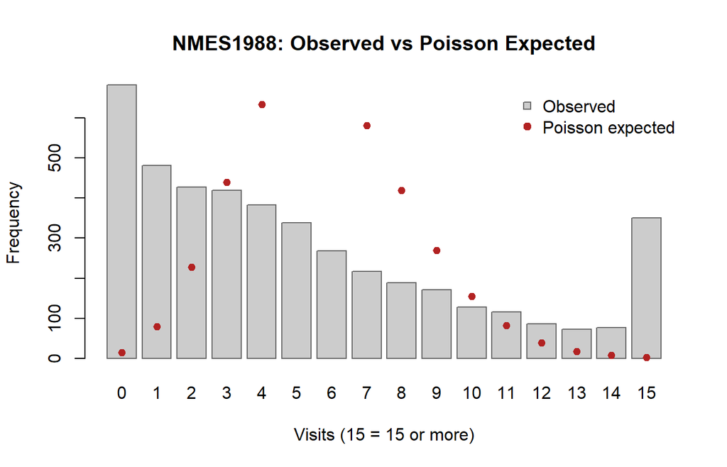

Observed visit counts (bars) vs Poisson expected (points). The Poisson severely under-predicts zeros and over-predicts moderate counts.

The variance (45.69) far exceeds the mean (5.77), indicating overdispersion. The observed proportion of zeros (0.155) exceeds the Poisson prediction (0.003), suggesting excess zeros.

## 6.2 Model Fitting

We fit a Poisson GLM with `glm()` (for reference only), and NB and ZINB models with **nbzinbAmoah**. As specified in the project description, the count model uses `hospital`, `health`, `chronic`, `gender`, `school` and `insurance`, and the zero model uses `hospital`, `chronic`, `gender`, `school` and `insurance`.

## 6.3 Model Comparison

Model comparison for NMES1988 (observed zeros = 683)

| Model | df | logLik | AIC | BIC | ExpZeros |
| --- | --- | --- | --- | --- | --- |
| Poisson | 8 | -17971.6 | 35959.2 | 36010.4 | 46.7 |
| NB | 9 | -12170.6 | 24359.1 | 24416.6 | 608.0 |
| ZINB | 15 | -12090.7 | 24211.4 | 24307.3 | 708.9 |

## 6.4 Interpretation

NB model: incidence rate ratios (IRR) with 95% Wald CIs. Values above 1 indicate higher visit rates.

| Covariate | IRR | 95% CI |
| --- | --- | --- |
| hospital | 1.243 | (1.195, 1.293) |
| healthpoor | 1.357 | (1.234, 1.492) |
| healthexcellent | 0.710 | (0.631, 0.801) |
| chronic | 1.191 | (1.163, 1.220) |
| gendermale | 0.881 | (0.829, 0.937) |
| school | 1.027 | (1.018, 1.036) |
| insuranceyes | 1.252 | (1.158, 1.352) |

ZINB zero part: odds ratios for being a structural zero

| Covariate | OR | 95% CI | p-value |
| --- | --- | --- | --- |
| hospital | 0.449 | (0.197, 1.025) | 0.0571 |
| chronic | 0.287 | (0.202, 0.407) | <1e-04 |
| gendermale | 1.911 | (1.291, 2.829) | 0.0012 |
| school | 0.920 | (0.874, 0.968) | 0.0014 |
| insuranceyes | 0.309 | (0.200, 0.475) | <1e-04 |

**Dispersion.** The NB model estimates $\hat\theta$ = 1.207 (SE of $\log\hat\theta$ = 0.028). At the mean visit count of 5.77, the NB variance $\mu + \mu^2/\theta$ is therefore about 33.4, compared with 5.77 under the Poisson model. The ZINB count part has $\log\hat\theta$ = 0.394 (SE 0.035), $\hat\theta$ = 1.483.

For the NB model each additional hospital stay is associated with 24% more physician visits. People in poor health make 36% more visits than people in average health. Those in excellent health make 29% fewer visits. Each chronic condition is associated with 19% more visits. Men make 12% fewer visits than women. Having insurance is associated with 25% more visits.

The ZINB count part shows the same pattern as the NB model; hospital stays, poor health, chronic conditions, and insurance all increase visits, while excellent health and being male reduce visits. The effects are slightly smaller because some zeros are now handled by the zero part.

The zero part shows who never visits a doctor. People with chronic conditions are less likely to be non-visitors (OR = 0.287) because they have no choice but to seek care. Men are almost twice as likely as women to never visit a doctor (OR = 1.911). People with insurance are much less likely to be non-visitors (OR = 0.309), suggesting cost keeps some people away. More education also slightly reduces the chance of never visiting (OR = 0.920). Hospital stays were not significant with p = 0.057.

## 6.5 Model Choice

The Poisson model fits very poorly. Its log-likelihood is 5801 lower than the NB model’s, and it predicts only 47 zeros against 683 observed. Allowing overdispersion fixes most of the problem, but the NB model still under-predicts zeros (608 expected). The ZINB model improves the log-likelihood by a further 79.8 with 6 extra parameters, predicts 709 zeros, and has the lowest AIC **and** the lowest BIC.

We therefore prefer the **ZINB model** for NMES1988. For the bioChemists data in Appendix A of the project description, BIC favoured the simpler NB model; here, the evidence for excess zeros is strong enough to survive BIC’s larger penalty. The zero part also adds a useful interpretation: it identifies a group of structural non-users of physician care, who are more likely to be male, uninsured, less educated and to have fewer chronic conditions.

# 7 Discussion

This project implemented NB and ZINB regression from scratch, using only IRLS and Newton–Raphson (NB) and an EM algorithm with IRLS M-steps (ZINB). No general-purpose optimizer was used in the fitting code.

The benchmarking results confirm that our implementation reproduces `MASS::glm.nb()` to within 3.72e-10 and `pscl::zeroinfl()` to within 1.51e-05 for coefficients, with log-likelihood differences of at most 9.97e-10. These are well within the required tolerances ($10^{-5}$ for NB and $10^{-3}$ for ZINB coefficients).

The simulation study ($R$ = 100, $n$ = 500) shows that `zinbreg()` reliably recovers known ZINB parameters with negligible bias and well-calibrated 95% Wald intervals (empirical coverage 0.93–0.95).

**Limitations.** First, the NB standard errors for $\beta$ treat $\theta$ as known, as `glm.nb()` does, so they ignore the uncertainty in $\hat\theta$. Second, the ZINB standard errors use a numerical Hessian, which is slower and can be less accurate than an analytic one. Third, EM converges linearly, so `zinbreg()` needs many iterations and is several times slower than `zeroinfl()` (see the timing table). Fourth, offsets are supported in the count model only, not in the zero model. Finally, in the NMES1988 analysis the zero-model covariates follow the project description, and the choice between NB and ZINB relies on information criteria rather than a formal test, because the usual likelihood-ratio test is non-standard when the null value $\pi_i = 0$ lies on the boundary of the parameter space.

**Possible extensions** include an analytic Hessian for the ZINB standard errors, an offset in the zero model, acceleration of the EM algorithm (for example, switching to Newton–Raphson near convergence), and a formal score test for zero inflation.

# 8 AI-Use Statement

I used Claude.ai together with claude code and vscode to write the main functions, nbreg() and zinbreg(), including the IRLS, Newton-Raphson, and EM algorithms. It also helped me set up the GitHub repository, prepare the benchmark scripts, run the simulation study, create the pkgdown website, and draft the report. I followed the process by providing instructions based on the equations and requirements in the project description.

I read the project description to understand the statistical methods. I also checked the benchmark comparisons results agreed with MASS::glm.nb() and pscl::zeroinfl() within the required tolerances. I reviewed the report, checked the results, and made changes to the wording where necessary.

I noticed a function that Claude used inside the package that caused an error during testing. I read the error message, and asked Claude to use a different approach, “solve(crossprod())”. That actually worked.

# 9 References

Deb, Partha, and Pravin K. Trivedi. 1997. “Demand for Medical Care by the Elderly: A Finite Mixture Approach.” *Journal of Applied Econometrics* 12 (3): 313–36.

Dempster, A. P., N. M. Laird, and D. B. Rubin. 1977. “Maximum Likelihood from Incomplete Data via the EM Algorithm.” *Journal of the Royal Statistical Society, Series B* 39 (1): 1–38.

Kleiber, Christian, and Achim Zeileis. 2008. *Applied Econometrics with R*. Springer.

Lambert, Diane. 1992. “Zero-Inflated Poisson Regression, with an Application to Defects in Manufacturing.” *Technometrics* 34 (1): 1–14.

McCullagh, P., and J. A. Nelder. 1989. *Generalized Linear Models*. 2nd ed. Chapman & Hall.

Venables, W. N., and B. D. Ripley. 2002. *Modern Applied Statistics with S*. 4th ed. Springer.

Zeileis, Achim, Christian Kleiber, and Simon Jackman. 2008. “Regression Models for Count Data in R.” *Journal of Statistical Software* 27 (8): 1–25.

# 10 Appendix A: Full Model Output for bioChemists

The `pscl::bioChemists` dataset records the number of articles published by 915 PhD biochemists in their last three years.

## 10.1 NB Model

```
Negative Binomial Regression
Call: nbreg(formula = f_bio_nb, data = bioChemists, control = ctrl_nb)

Coefficients:
             Estimate Std. Error z value Pr(>|z|)
(Intercept)  0.256144   0.137348   1.865 0.062191 .
femWomen    -0.216418   0.072636  -2.979 0.002887 **
marMarried   0.150489   0.082097   1.833 0.066791 .
kid5        -0.176415   0.052813  -3.340 0.000837 ***
phd          0.015271   0.035873   0.426 0.670326
ment         0.029082   0.003214   9.048  < 2e-16 ***
---
Signif. codes:  0 '***' 0.001 '**' 0.01 '*' 0.05 '.' 0.1 ' ' 1

Theta: 2.2644  (SE of log-theta: 0.1198)
Log-likelihood: -1560.9583 on 908 Df
n = 915  Converged: TRUE  Iterations: 4
```

## 10.2 ZINB Model

```
Zero-Inflated Negative Binomial Regression
Call: zinbreg(formula = f_bio_zinb, data = bioChemists, control = ctrl_zinb)


Count model coefficients (NB with log link):
              Estimate Std. Error z value Pr(>|z|)
(Intercept)  0.4167468  0.1435960   2.902  0.00371 **
femWomen    -0.1955066  0.0755925  -2.586  0.00970 **
marMarried   0.0975827  0.0844519   1.155  0.24789
kid5        -0.1517323  0.0542061  -2.799  0.00512 **
phd         -0.0007001  0.0362695  -0.019  0.98460
ment         0.0247862  0.0034924   7.097 1.27e-12 ***
---
Signif. codes:  0 '***' 0.001 '**' 0.01 '*' 0.05 '.' 0.1 ' ' 1

Log(theta): 0.9764  (SE: 0.1355)  =>  theta = 2.6548

Zero-inflation model coefficients (binomial with logit link):
            Estimate Std. Error z value Pr(>|z|)
(Intercept) -0.19170    1.32281  -0.145  0.88477
femWomen     0.63593    0.84891   0.749  0.45379
marMarried  -1.49945    0.93866  -1.597  0.11017
kid5         0.62843    0.44278   1.419  0.15582
phd         -0.03771    0.30801  -0.122  0.90255
ment        -0.88229    0.31622  -2.790  0.00527 **
---
Signif. codes:  0 '***' 0.001 '**' 0.01 '*' 0.05 '.' 0.1 ' ' 1

Log-likelihood: -1549.9909 on 902 Df
n = 915  Converged: TRUE  Iterations: 135
```